# 777 Univariado

# Caracterización

A continuación se muestran los estadísticos descriptivos de las variables correspondientes a la caracterización de la muestra…

## Edad.

A continuaciï¿½n se presentan las estadï¿½sticas de la variable (`Edad.`)

Resumen de Edad.

|  | Min. | 1st Qu. | Median | Mean | 3rd Qu. | Max. | Var | S.D. |
| --- | --- | --- | --- | --- | --- | --- | --- | --- |
| . | 17 | 21 | 23 | 23.99 | 26 | 46 | 23.47 | 4.85 |

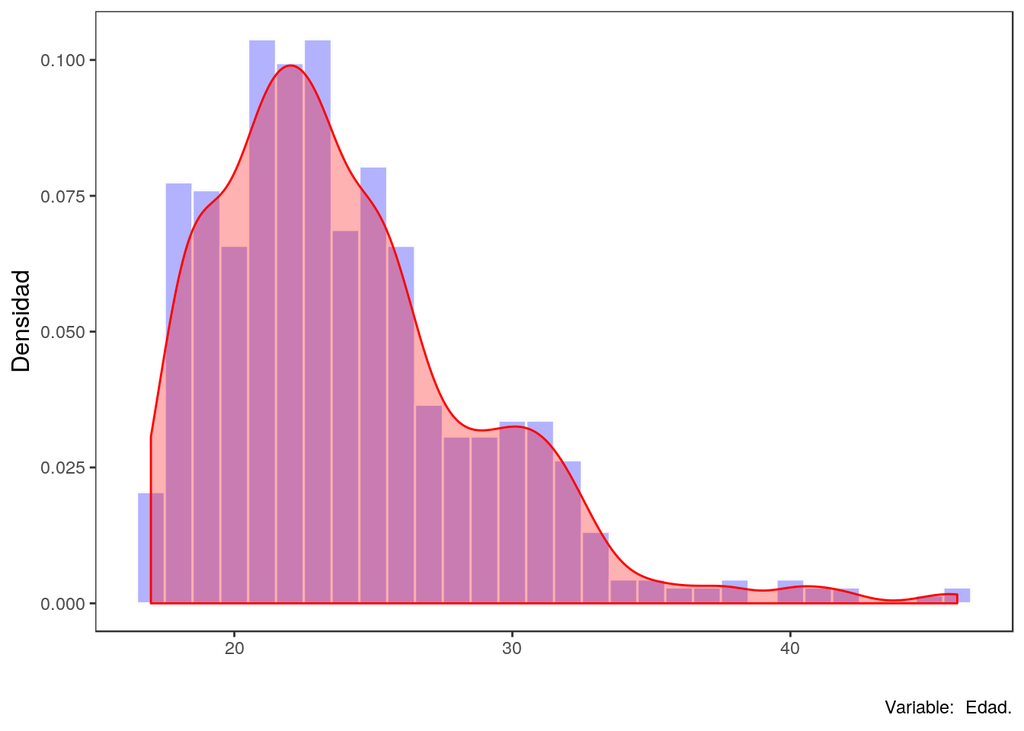

## Edad de primer relaciones sexual (coital, oral o anal).

A continuaciï¿½n se presentan las estadï¿½sticas de la variable (`Edad de primer relaciones sexual (coital, oral o anal).`)

Resumen de Edad de primer relaciones sexual (coital, oral o anal).

|  | Min. | 1st Qu. | Median | Mean | 3rd Qu. | Max. | NA’s | Var | S.D. |
| --- | --- | --- | --- | --- | --- | --- | --- | --- | --- |
| . | 0 | 15 | 17 | 16.9 | 18 | 30 | 9 | 7.74 | 2.78 |

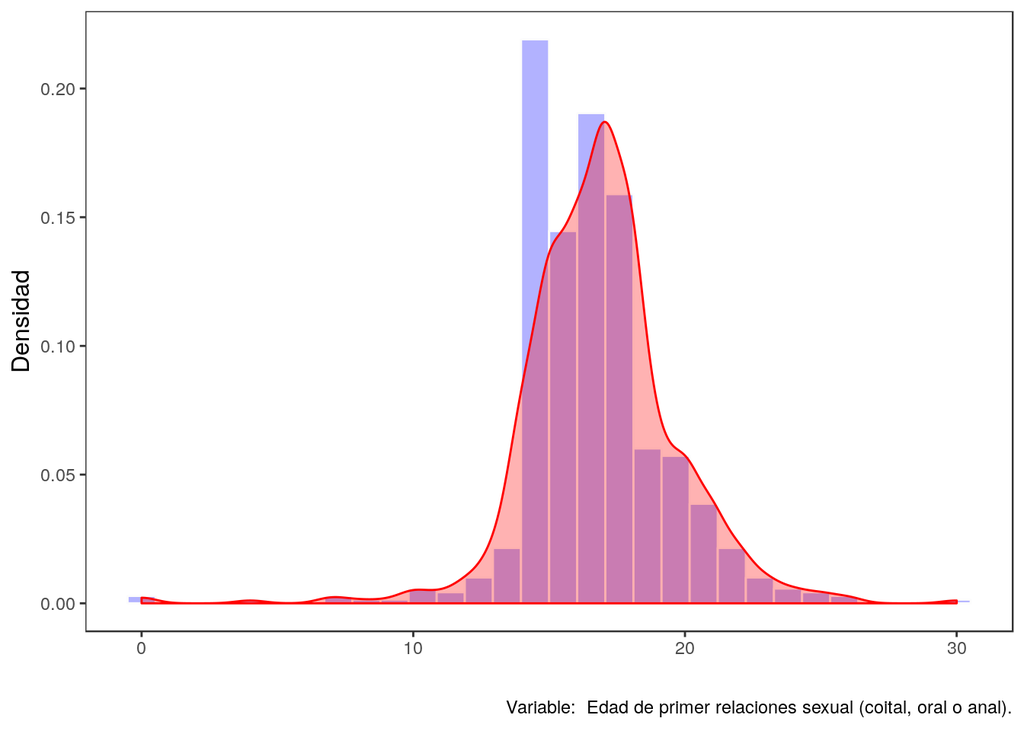

## NÃºmero de parejas sexuales durante la vida.

A continuaciï¿½n se presentan las estadï¿½sticas de la variable (`NÃºmero de parejas sexuales durante la vida.`)

Resumen de NÃºmero de parejas sexuales durante la vida.

|  | Min. | 1st Qu. | Median | Mean | 3rd Qu. | Max. | NA’s | Var | S.D. |
| --- | --- | --- | --- | --- | --- | --- | --- | --- | --- |
| . | 0 | 2 | 5 | 9.61 | 9 | 425 | 2 | 680.51 | 26.09 |

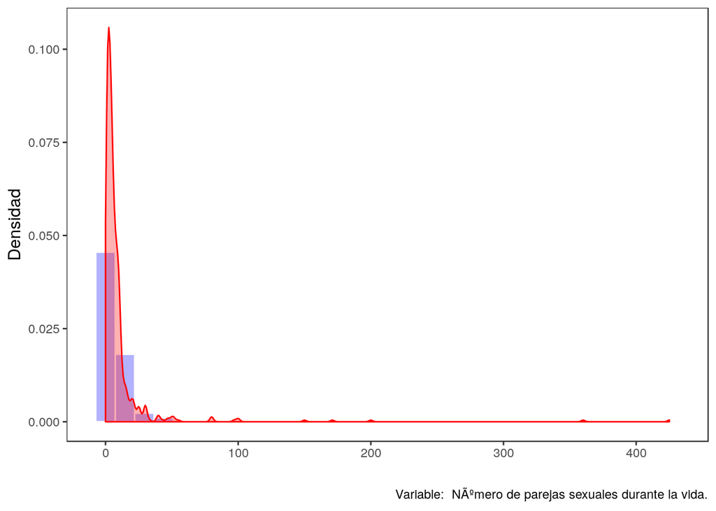

## Número de parejas sexuales durante el último año.

A continuaciï¿½n se presentan las estadï¿½sticas de la variable (`Número de parejas sexuales durante el último año.`)

Resumen de Número de parejas sexuales durante el último año.

|  | Min. | 1st Qu. | Median | Mean | 3rd Qu. | Max. | NA’s | Var | S.D. |
| --- | --- | --- | --- | --- | --- | --- | --- | --- | --- |
| . | 0 | 1 | 1 | 2.21 | 2 | 30 | 2 | 8.74 | 2.96 |

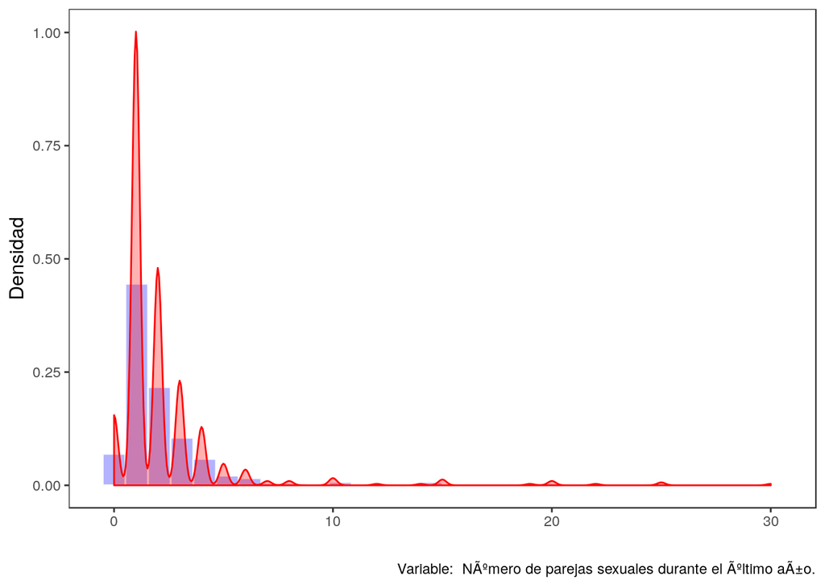

## ReligiÃ³n.

A continuaciï¿½n se presentan las estadï¿½sticas de la variable (`ReligiÃ³n.`)

Tabla de Frecuencia

| Categorï¿½a | Frecuencia abs | Frecuencia rel. (%) |
| --- | --- | --- |
| Agnóstico | 100 | 14.62 |
| Católico | 133 | 19.44 |
| Cristiano | 41 | 5.99 |
| No profeso ninguna religión. | 377 | 55.12 |
| Otra religión | 33 | 4.82 |

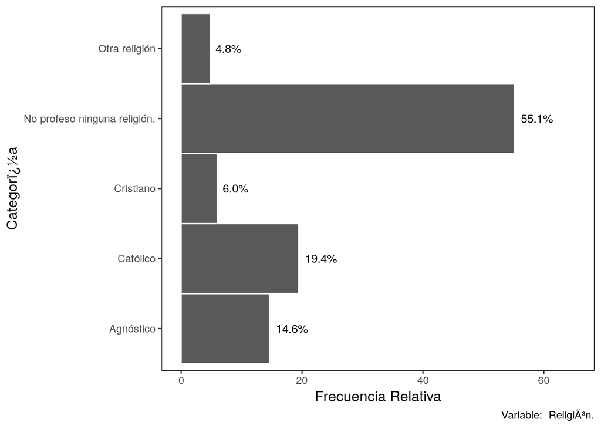

## Sexo.

A continuaciï¿½n se presentan las estadï¿½sticas de la variable (`Sexo.`)

Tabla de Frecuencia

| Categorï¿½a | Frecuencia abs | Frecuencia rel. (%) |
| --- | --- | --- |
| Femenino | 359 | 52.49 |
| Masculino | 325 | 47.51 |

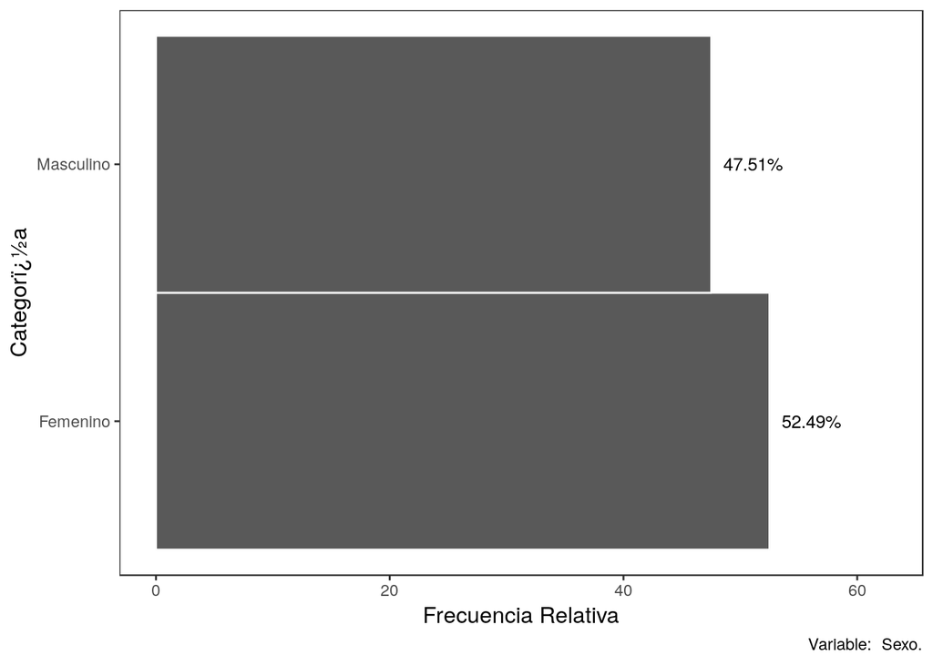

## OrientaciÃ³n sexual.

A continuaciï¿½n se presentan las estadï¿½sticas de la variable (`OrientaciÃ³n sexual.`)

Tabla de Frecuencia

| Categorï¿½a | Frecuencia abs | Frecuencia rel. (%) |
| --- | --- | --- |
| Antrosexual. | 1 | 0.15 |
| Bisexual. | 113 | 16.52 |
| Demisexual. | 3 | 0.44 |
| Heterosexual. | 481 | 70.32 |
| Homosexual. | 60 | 8.77 |
| Otra. | 7 | 1.02 |
| Pansexual. | 17 | 2.49 |
| Transexual. | 2 | 0.29 |

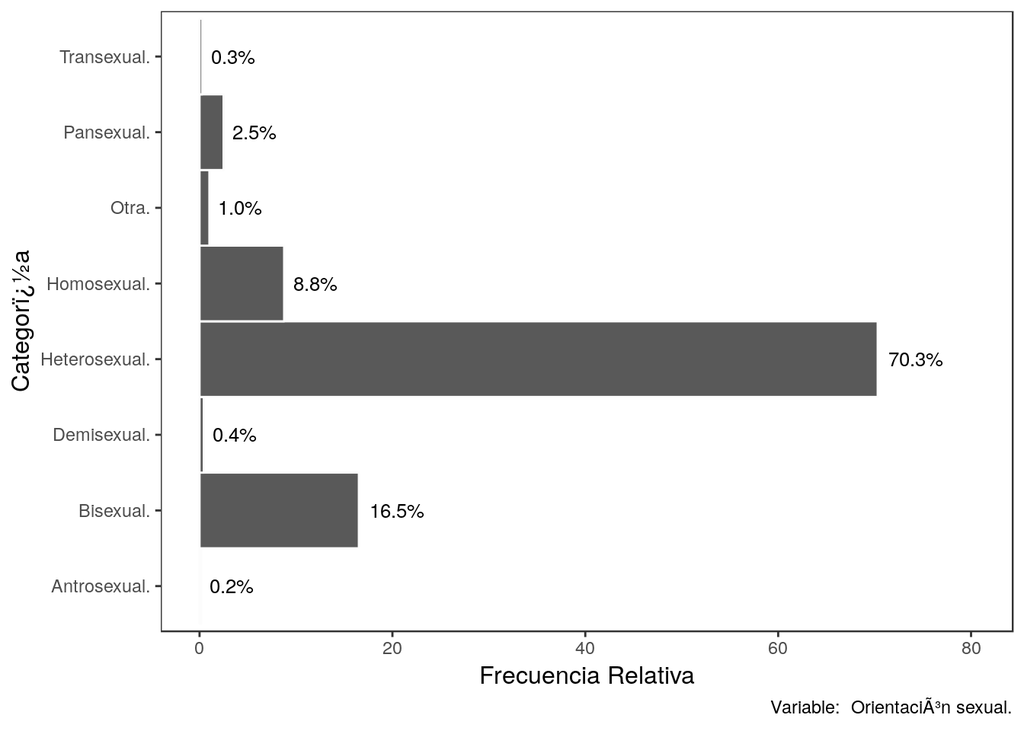

## Â¿He tenido o tiene alguna ETS o ITS?

A continuaciï¿½n se presentan las estadï¿½sticas de la variable (`Â¿He tenido o tiene alguna ETS o ITS?`)

Tabla de Frecuencia

| Categorï¿½a | Frecuencia abs | Frecuencia rel. (%) |
| --- | --- | --- |
| No | 618 | 90.35 |
| Sí | 66 | 9.65 |

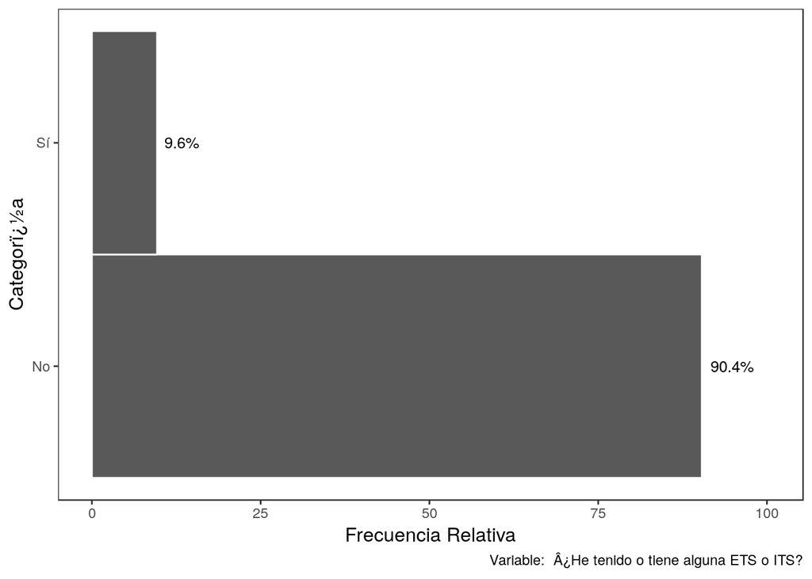

## Â¿Alguna vez usted o su pareja ha quedado en embarazo?

A continuaciï¿½n se presentan las estadï¿½sticas de la variable (`Â¿Alguna vez usted o su pareja ha quedado en embarazo?`)

Tabla de Frecuencia

| Categorï¿½a | Frecuencia abs | Frecuencia rel. (%) |
| --- | --- | --- |
| No | 476 | 69.59 |
| No aplica | 88 | 12.87 |
| Sí | 120 | 17.54 |

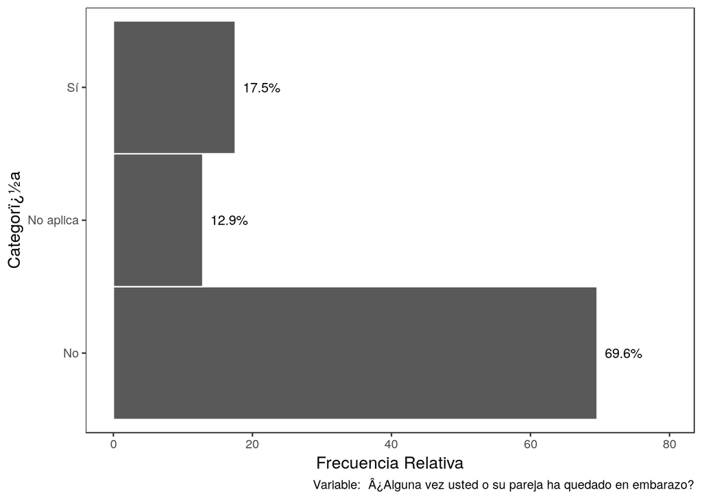

## Â¿En la actualidad tiene pareja sexual estable?

A continuaciï¿½n se presentan las estadï¿½sticas de la variable (`Â¿En la actualidad tiene pareja sexual estable?`)

Tabla de Frecuencia

| Categorï¿½a | Frecuencia abs | Frecuencia rel. (%) |
| --- | --- | --- |
| No | 289 | 42.25 |
| Sí | 395 | 57.75 |

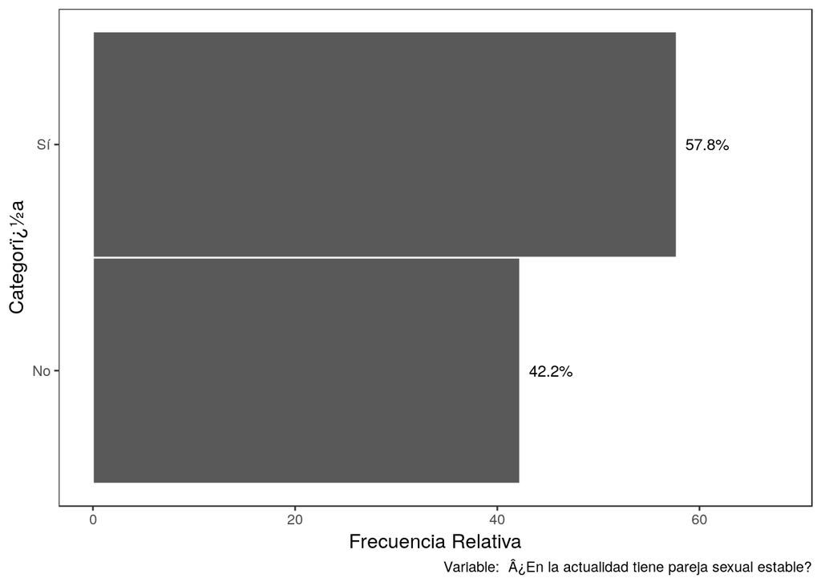

## Usted se considera

A continuaciï¿½n se presentan las estadï¿½sticas de la variable (`Usted se considera`)

Tabla de Frecuencia

| Categorï¿½a | Frecuencia abs | Frecuencia rel. (%) |
| --- | --- | --- |
| Monógamo. | 537 | 78.51 |
| Polígamo. | 147 | 21.49 |

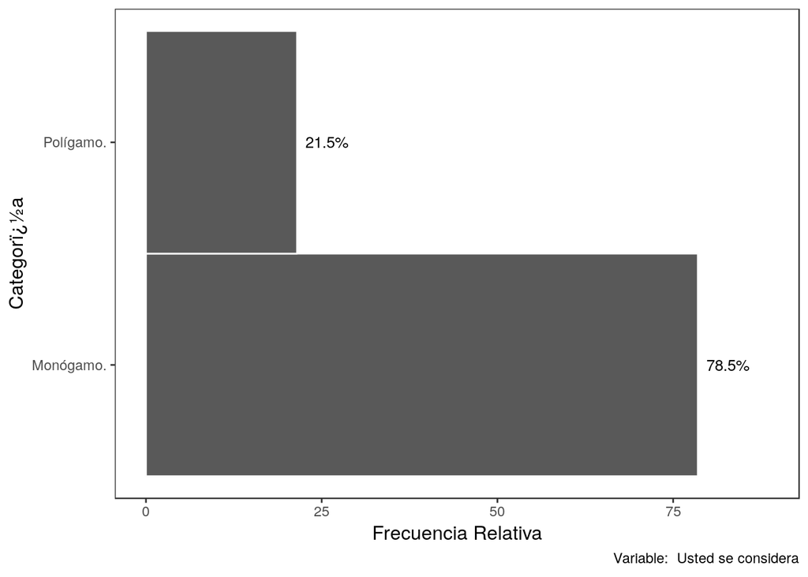

# Práctica

A continuación se muestran los estadísticos descriptivos de las variables correspondientes a la práctica de la muestra…

## He tenido relaciones sexuales sin condÃ³n.

A continuaciï¿½n se presentan las estadï¿½sticas de la variable (`He tenido relaciones sexuales sin condÃ³n.`)

Tabla de Frecuencia

| Categorï¿½a | Frecuencia abs | Frecuencia rel. (%) |
| --- | --- | --- |
| Nunca/No aplica. | 313 | 45.76 |
| Más de un año. | 78 | 11.40 |
| Último año. | 87 | 12.72 |
| Últimos 6 meses. | 46 | 6.73 |
| Últimos 3 meses. | 95 | 13.89 |
| En el Último mes. | 65 | 9.50 |

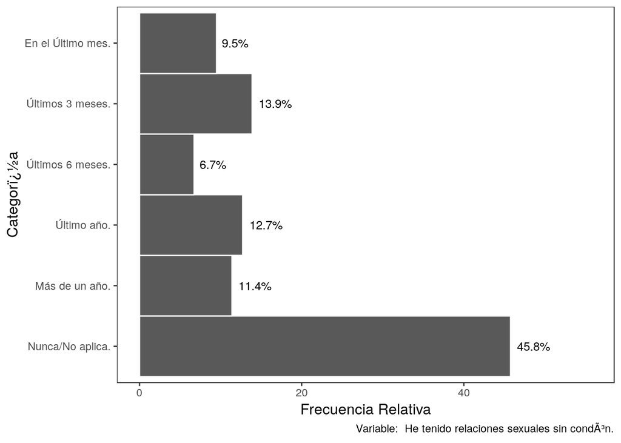

## He tenido sexo bajo efectos del alcohol.

A continuaciï¿½n se presentan las estadï¿½sticas de la variable (`He tenido sexo bajo efectos del alcohol.`)

Tabla de Frecuencia

| Categorï¿½a | Frecuencia abs | Frecuencia rel. (%) |
| --- | --- | --- |
| Nunca/No aplica. | 83 | 12.13 |
| Más de un año. | 131 | 19.15 |
| Último año. | 222 | 32.46 |
| Últimos 6 meses. | 80 | 11.70 |
| Últimos 3 meses. | 100 | 14.62 |
| En el Último mes. | 68 | 9.94 |

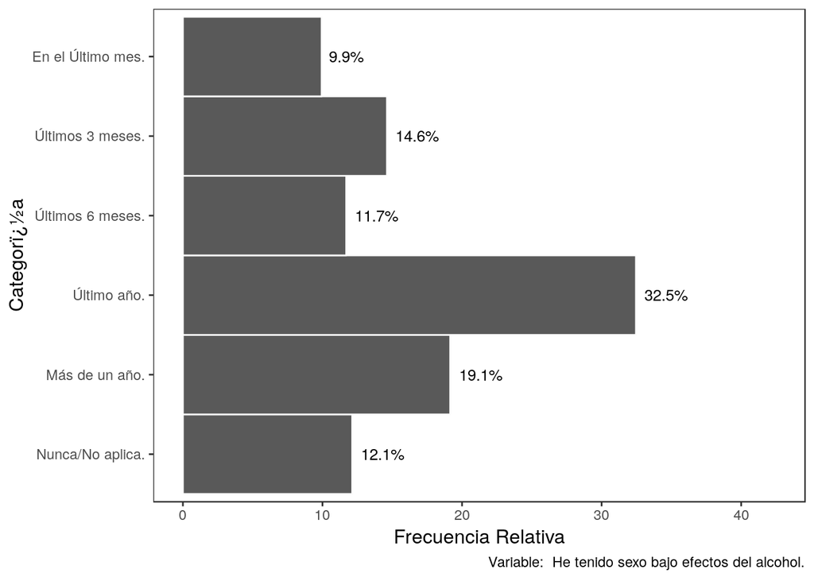

## He practicado sexo bajo efectos de sustancias psico-activas.

A continuaciï¿½n se presentan las estadï¿½sticas de la variable (`He practicado sexo bajo efectos de sustancias psico-activas.`)

Tabla de Frecuencia

| Categorï¿½a | Frecuencia abs | Frecuencia rel. (%) |
| --- | --- | --- |
| Nunca/No aplica. | 80 | 11.70 |
| Más de un año. | 84 | 12.28 |
| Último año. | 396 | 57.89 |
| Últimos 6 meses. | 29 | 4.24 |
| Últimos 3 meses. | 52 | 7.60 |
| En el Último mes. | 43 | 6.29 |

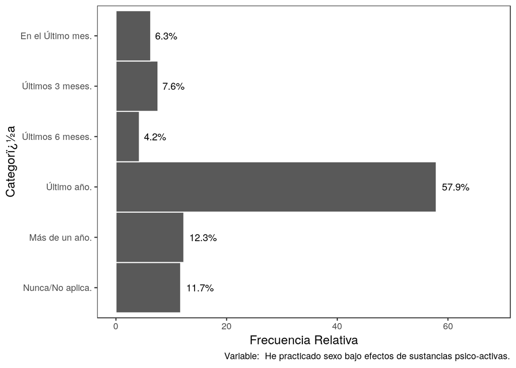

## He practicado sexo grupal.

A continuaciï¿½n se presentan las estadï¿½sticas de la variable (`He practicado sexo grupal.`)

Tabla de Frecuencia

| Categorï¿½a | Frecuencia abs | Frecuencia rel. (%) |
| --- | --- | --- |
| Nunca/No aplica. | 11 | 1.61 |
| Más de un año. | 66 | 9.65 |
| Último año. | 569 | 83.19 |
| Últimos 6 meses. | 20 | 2.92 |
| Últimos 3 meses. | 4 | 0.58 |
| En el Último mes. | 14 | 2.05 |

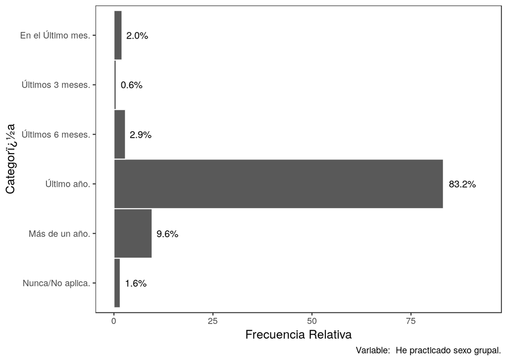

## He ofrecido o hecho uso de servicios sexuales.

A continuaciï¿½n se presentan las estadï¿½sticas de la variable (`He ofrecido o hecho uso de servicios sexuales.`)

Tabla de Frecuencia

| Categorï¿½a | Frecuencia abs | Frecuencia rel. (%) |
| --- | --- | --- |
| Nunca/No aplica. | 12 | 1.75 |
| Más de un año. | 44 | 6.43 |
| Último año. | 598 | 87.43 |
| Últimos 6 meses. | 8 | 1.17 |
| Últimos 3 meses. | 11 | 1.61 |
| En el Último mes. | 11 | 1.61 |

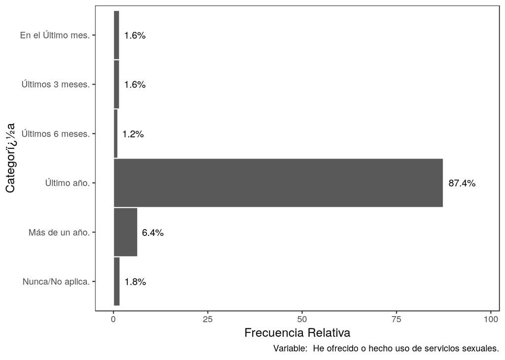

## He sido infiel sexualmente.

A continuaciï¿½n se presentan las estadï¿½sticas de la variable (`He sido infiel sexualmente.`)

Tabla de Frecuencia

| Categorï¿½a | Frecuencia abs | Frecuencia rel. (%) |
| --- | --- | --- |
| Nunca/No aplica. | 41 | 5.99 |
| Más de un año. | 125 | 18.27 |
| Último año. | 411 | 60.09 |
| Últimos 6 meses. | 33 | 4.82 |
| Últimos 3 meses. | 39 | 5.70 |
| En el Último mes. | 35 | 5.12 |

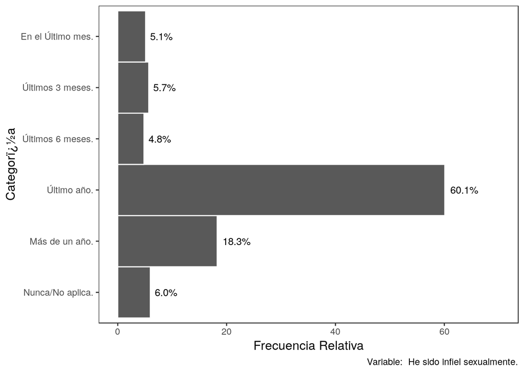

## He tenido relaciones sexuales con un reciÃ©n conocido.

A continuaciï¿½n se presentan las estadï¿½sticas de la variable (`He tenido relaciones sexuales con un reciÃ©n conocido.`)

Tabla de Frecuencia

| Categorï¿½a | Frecuencia abs | Frecuencia rel. (%) |
| --- | --- | --- |
| Nunca/No aplica. | 53 | 7.75 |
| Más de un año. | 139 | 20.32 |
| Último año. | 363 | 53.07 |
| Últimos 6 meses. | 41 | 5.99 |
| Últimos 3 meses. | 43 | 6.29 |
| En el Último mes. | 45 | 6.58 |

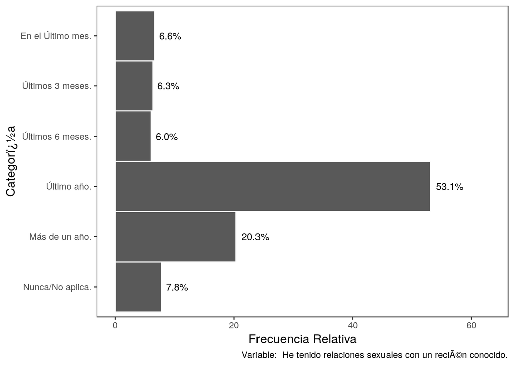

## He experimentados sustos de embarazo o ETS.

A continuaciï¿½n se presentan las estadï¿½sticas de la variable (`He experimentados sustos de embarazo o ETS.`)

Tabla de Frecuencia

| Categorï¿½a | Frecuencia abs | Frecuencia rel. (%) |
| --- | --- | --- |
| Nunca/No aplica. | 51 | 7.46 |
| Más de un año. | 219 | 32.02 |
| Último año. | 204 | 29.82 |
| Últimos 6 meses. | 85 | 12.43 |
| Últimos 3 meses. | 55 | 8.04 |
| En el Último mes. | 70 | 10.23 |

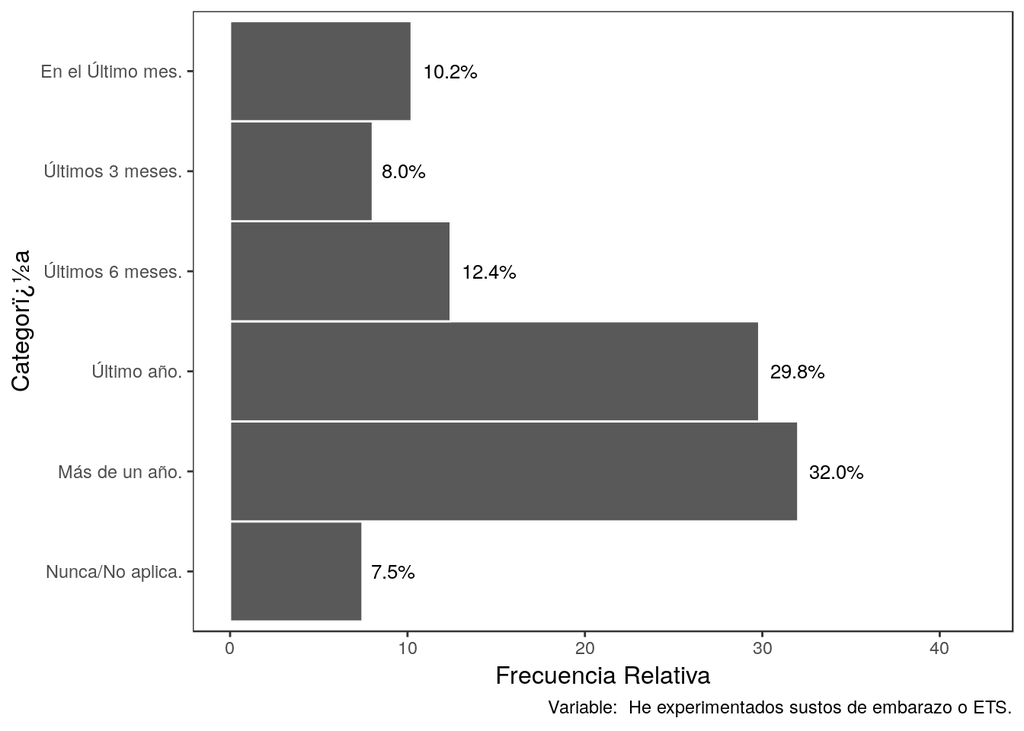

## Me he realizado exámenes médicos (VIH, citologías, entre otros)

A continuaciï¿½n se presentan las estadï¿½sticas de la variable (`Me he realizado exámenes médicos (VIH, citologías, entre otros)`)

Tabla de Frecuencia

| Categorï¿½a | Frecuencia abs | Frecuencia rel. (%) |
| --- | --- | --- |
| Nunca/No aplica. | 62 | 9.06 |
| Más de un año. | 148 | 21.64 |
| Último año. | 211 | 30.85 |
| Últimos 6 meses. | 109 | 15.94 |
| Últimos 3 meses. | 68 | 9.94 |
| En el Último mes. | 86 | 12.57 |

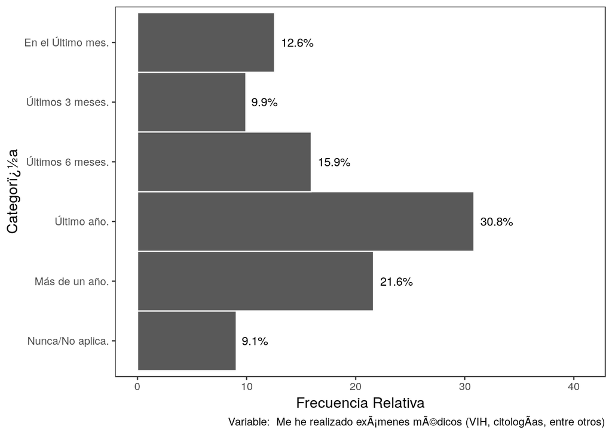

## He tomado post-day / Mi pareja sexual ha tomado post-day.

A continuaciï¿½n se presentan las estadï¿½sticas de la variable (`He tomado post-day / Mi pareja sexual ha tomado post-day.`)

Tabla de Frecuencia

| Categorï¿½a | Frecuencia abs | Frecuencia rel. (%) |
| --- | --- | --- |
| Nunca/No aplica. | 35 | 5.12 |
| Más de un año. | 188 | 27.49 |
| Último año. | 309 | 45.18 |
| Últimos 6 meses. | 54 | 7.89 |
| Últimos 3 meses. | 50 | 7.31 |
| En el Último mes. | 48 | 7.02 |

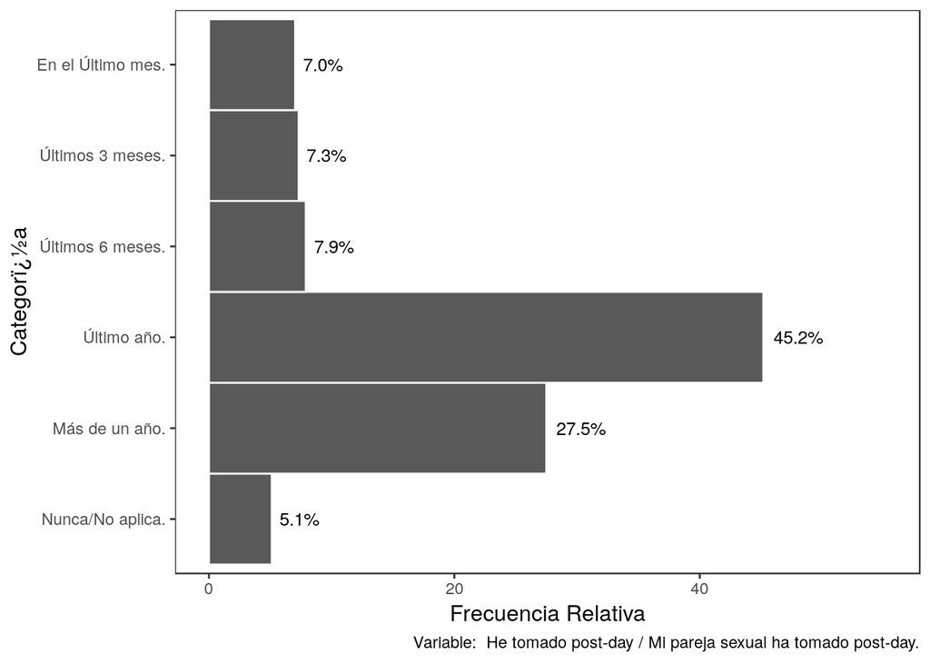

## He practicado el coito interrumpido.

A continuaciï¿½n se presentan las estadï¿½sticas de la variable (`He practicado el coito interrumpido.`)

Tabla de Frecuencia

| Categorï¿½a | Frecuencia abs | Frecuencia rel. (%) |
| --- | --- | --- |
| Nunca/No aplica. | 148 | 21.64 |
| Más de un año. | 111 | 16.23 |
| Último año. | 230 | 33.63 |
| Últimos 6 meses. | 43 | 6.29 |
| Últimos 3 meses. | 92 | 13.45 |
| En el Último mes. | 60 | 8.77 |

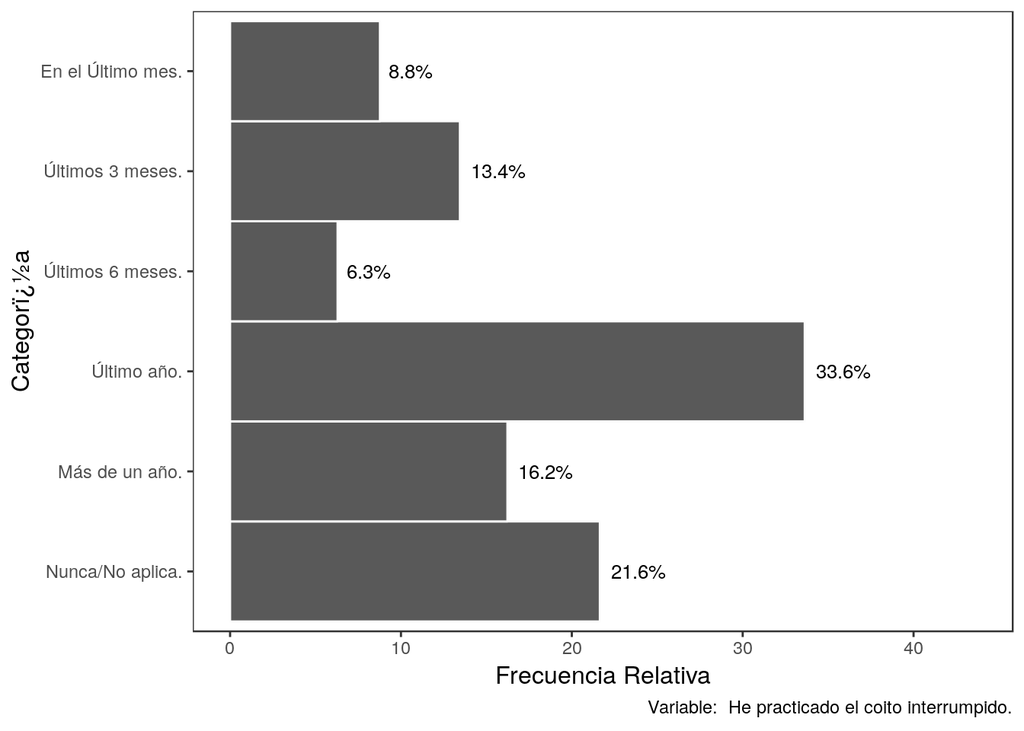

## He tenido relaciones sexuales tres días antes o después de la menstruación sin condón.

A continuaciï¿½n se presentan las estadï¿½sticas de la variable (`He tenido relaciones sexuales tres días antes o después de la menstruación sin condón.`)

Tabla de Frecuencia

| Categorï¿½a | Frecuencia abs | Frecuencia rel. (%) |
| --- | --- | --- |
| Nunca/No aplica. | 167 | 24.42 |
| Más de un año. | 74 | 10.82 |
| Último año. | 241 | 35.23 |
| Últimos 6 meses. | 44 | 6.43 |
| Últimos 3 meses. | 108 | 15.79 |
| En el Último mes. | 50 | 7.31 |

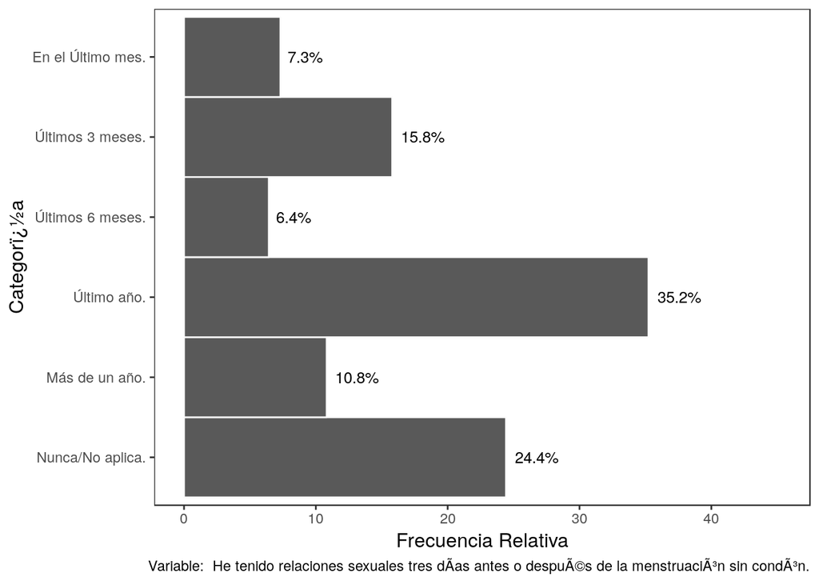

## He tenido relaciones basadas en besos y masturbaciÃ³n mutua.

A continuaciï¿½n se presentan las estadï¿½sticas de la variable (`He tenido relaciones basadas en besos y masturbaciÃ³n mutua.`)

Tabla de Frecuencia

| Categorï¿½a | Frecuencia abs | Frecuencia rel. (%) |
| --- | --- | --- |
| Nunca/No aplica. | 271 | 39.62 |
| Más de un año. | 120 | 17.54 |
| Último año. | 67 | 9.80 |
| Últimos 6 meses. | 44 | 6.43 |
| Últimos 3 meses. | 107 | 15.64 |
| En el Último mes. | 75 | 10.96 |

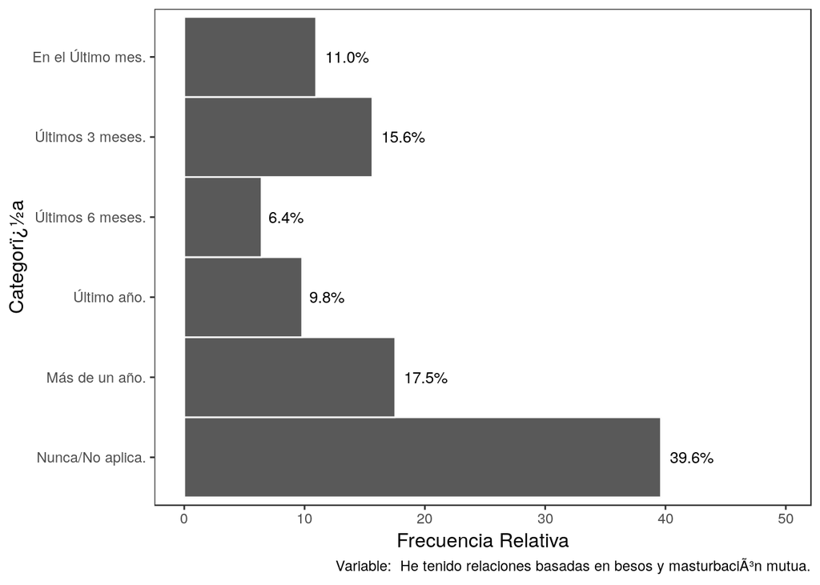

# Percepción de riesgo

A continuación se muestran los estadísticos descriptivos de las variables correspondientes a la percepción de riesgo de la muestra…

## Considero que tener relaciones sexuales sin condÃ³n es riesgoso.

A continuaciï¿½n se presentan las estadï¿½sticas de la variable (`Considero que tener relaciones sexuales sin condÃ³n es riesgoso.`)

Tabla de Frecuencia

| Categorï¿½a | Frecuencia abs | Frecuencia rel. (%) |
| --- | --- | --- |
| Totalmente De Acuerdo | 289 | 42.25 |
| De Acuerdo | 41 | 5.99 |
| Ni de acuerdo ni en desacuerdo | 68 | 9.94 |
| En Desacuerdo | 273 | 39.91 |
| Totalmente en Desacuerdo | 13 | 1.90 |

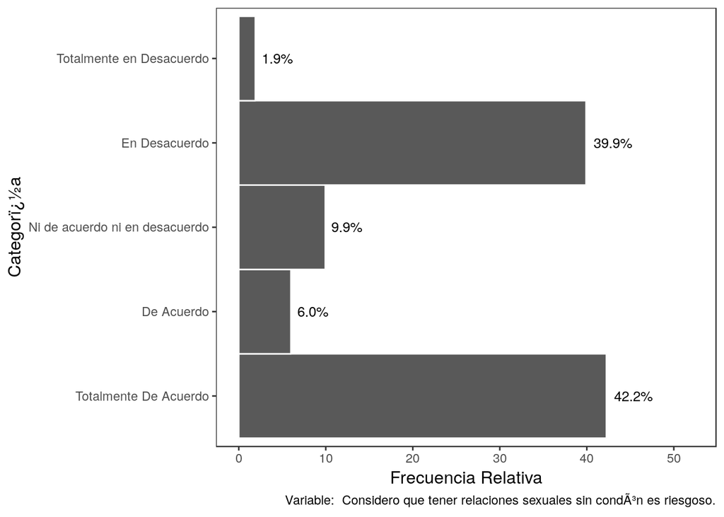

## Corro mayor riesgo al tener relaciones sexuales bajo efectos del alcohol.

A continuaciï¿½n se presentan las estadï¿½sticas de la variable (`Corro mayor riesgo al tener relaciones sexuales bajo efectos del alcohol.`)

Tabla de Frecuencia

| Categorï¿½a | Frecuencia abs | Frecuencia rel. (%) |
| --- | --- | --- |
| Totalmente De Acuerdo | 245 | 35.82 |
| De Acuerdo | 70 | 10.23 |
| Ni de acuerdo ni en desacuerdo | 137 | 20.03 |
| En Desacuerdo | 193 | 28.22 |
| Totalmente en Desacuerdo | 39 | 5.70 |

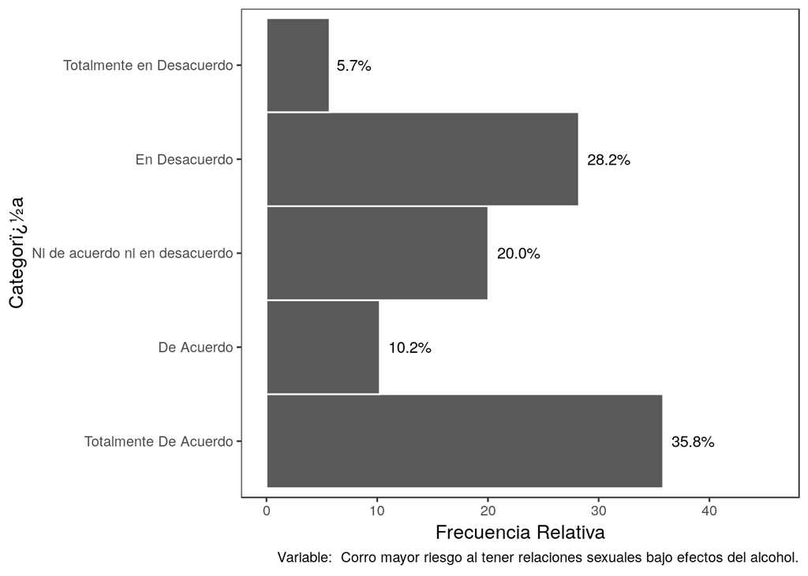

## Me gusta tener relaciones sexuales bajo efectos de sustancias psicoactivas.

A continuaciï¿½n se presentan las estadï¿½sticas de la variable (`Me gusta tener relaciones sexuales bajo efectos de sustancias psicoactivas.`)

Tabla de Frecuencia

| Categorï¿½a | Frecuencia abs | Frecuencia rel. (%) |
| --- | --- | --- |
| Totalmente De Acuerdo | 125 | 18.27 |
| De Acuerdo | 92 | 13.45 |
| Ni de acuerdo ni en desacuerdo | 178 | 26.02 |
| En Desacuerdo | 56 | 8.19 |
| Totalmente en Desacuerdo | 233 | 34.06 |

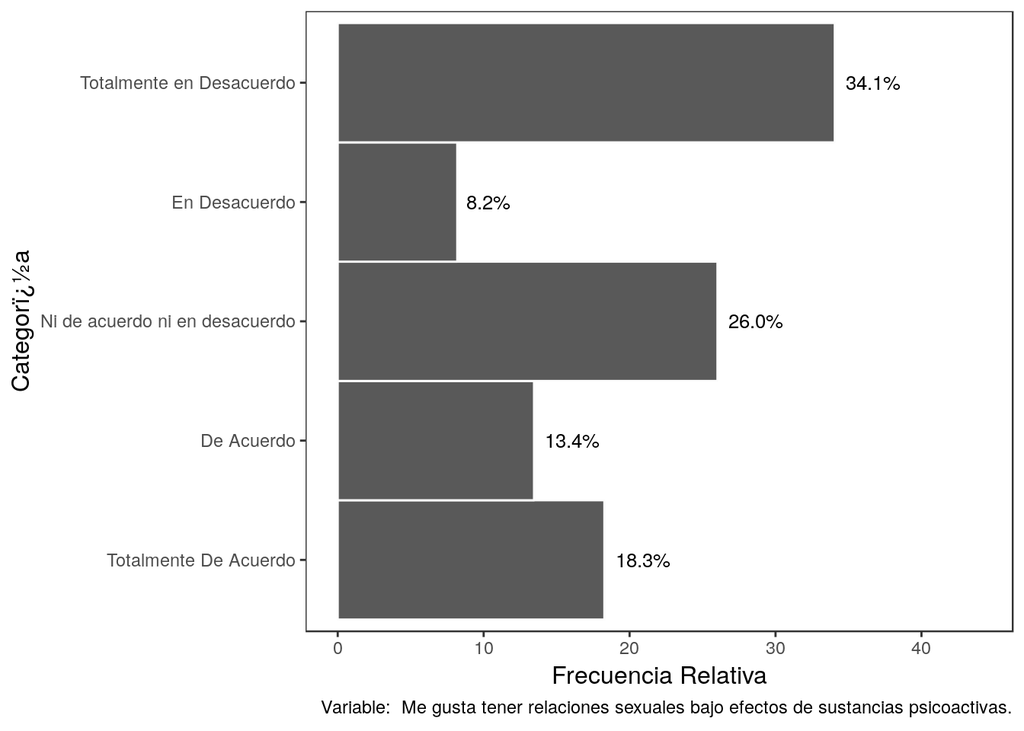

## Puedo tener relaciones sexuales grupales (incluido el intercambio de pareja) de forma segura.

A continuaciï¿½n se presentan las estadï¿½sticas de la variable (`Puedo tener relaciones sexuales grupales (incluido el intercambio de pareja) de forma segura.`)

Tabla de Frecuencia

| Categorï¿½a | Frecuencia abs | Frecuencia rel. (%) |
| --- | --- | --- |
| Totalmente De Acuerdo | 149 | 21.78 |
| De Acuerdo | 129 | 18.86 |
| Ni de acuerdo ni en desacuerdo | 162 | 23.68 |
| En Desacuerdo | 58 | 8.48 |
| Totalmente en Desacuerdo | 186 | 27.19 |

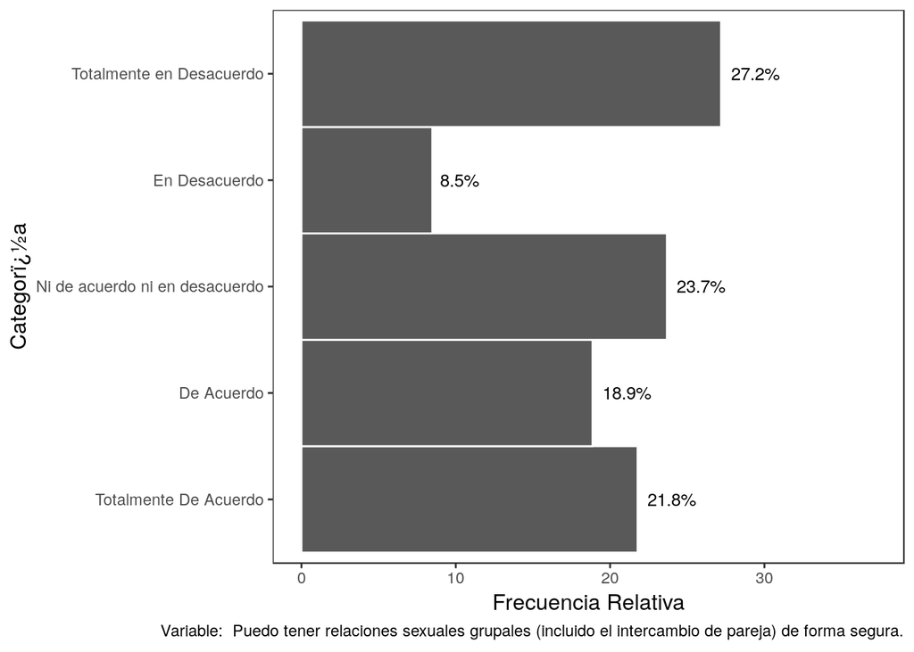

## No considero riesgoso para mi salud ofrecer o hacer uso de servicios sexuales.

A continuaciï¿½n se presentan las estadï¿½sticas de la variable (`No considero riesgoso para mi salud ofrecer o hacer uso de servicios sexuales.`)

Tabla de Frecuencia

| Categorï¿½a | Frecuencia abs | Frecuencia rel. (%) |
| --- | --- | --- |
| Totalmente De Acuerdo | 47 | 6.87 |
| De Acuerdo | 160 | 23.39 |
| Ni de acuerdo ni en desacuerdo | 101 | 14.77 |
| En Desacuerdo | 31 | 4.53 |
| Totalmente en Desacuerdo | 345 | 50.44 |

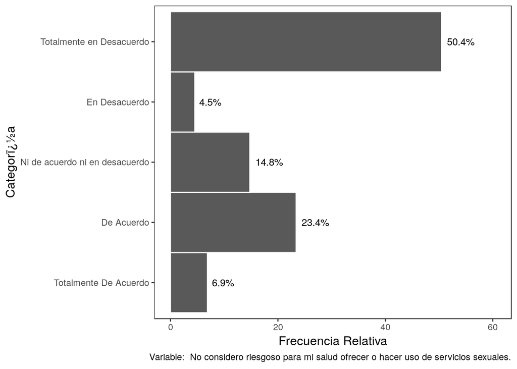

## El coito interrumpido es una método de planificación efectivo.

A continuaciï¿½n se presentan las estadï¿½sticas de la variable (`El coito interrumpido es una método de planificación efectivo.`)

Tabla de Frecuencia

| Categorï¿½a | Frecuencia abs | Frecuencia rel. (%) |
| --- | --- | --- |
| Totalmente De Acuerdo | 33 | 4.82 |
| De Acuerdo | 203 | 29.68 |
| Ni de acuerdo ni en desacuerdo | 101 | 14.77 |
| En Desacuerdo | 14 | 2.05 |
| Totalmente en Desacuerdo | 333 | 48.68 |

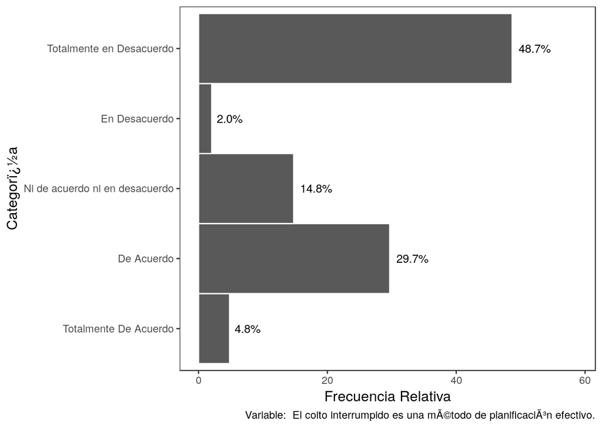

## Tener relaciones sexuales tres días antes o después de la menstruación es un buen método de planificación natural.

A continuaciï¿½n se presentan las estadï¿½sticas de la variable (`Tener relaciones sexuales tres días antes o después de la menstruación es un buen método de planificación natural.`)

Tabla de Frecuencia

| Categorï¿½a | Frecuencia abs | Frecuencia rel. (%) |
| --- | --- | --- |
| Totalmente De Acuerdo | 63 | 9.21 |
| De Acuerdo | 176 | 25.73 |
| Ni de acuerdo ni en desacuerdo | 199 | 29.09 |
| En Desacuerdo | 20 | 2.92 |
| Totalmente en Desacuerdo | 226 | 33.04 |

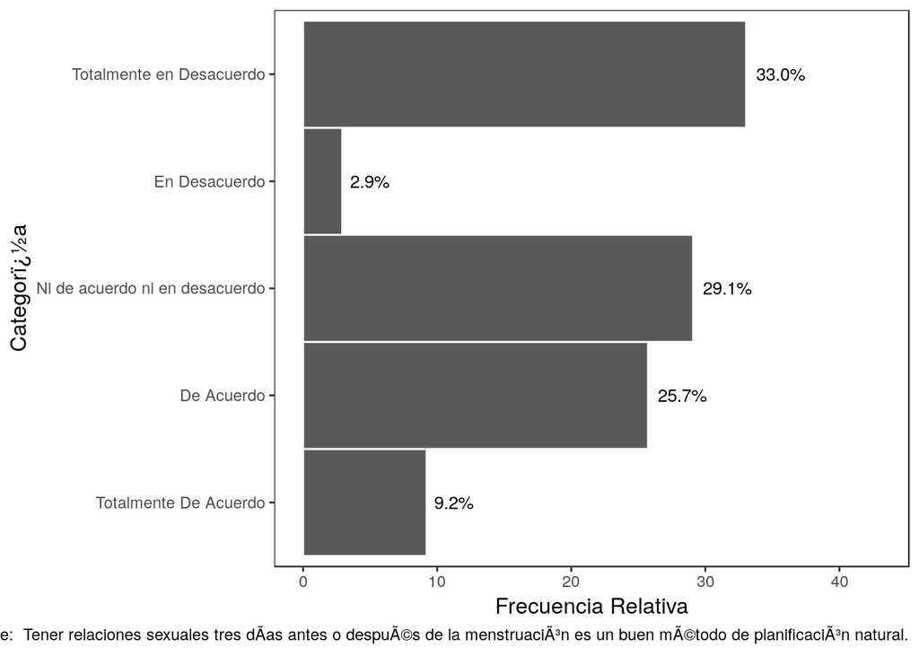

## La masturbación mutua es una práctica sexual segura.

A continuaciï¿½n se presentan las estadï¿½sticas de la variable (`La masturbación mutua es una práctica sexual segura.`)

Tabla de Frecuencia

| Categorï¿½a | Frecuencia abs | Frecuencia rel. (%) |
| --- | --- | --- |
| Totalmente De Acuerdo | 261 | 38.16 |
| De Acuerdo | 46 | 6.73 |
| Ni de acuerdo ni en desacuerdo | 157 | 22.95 |
| En Desacuerdo | 207 | 30.26 |
| Totalmente en Desacuerdo | 13 | 1.90 |

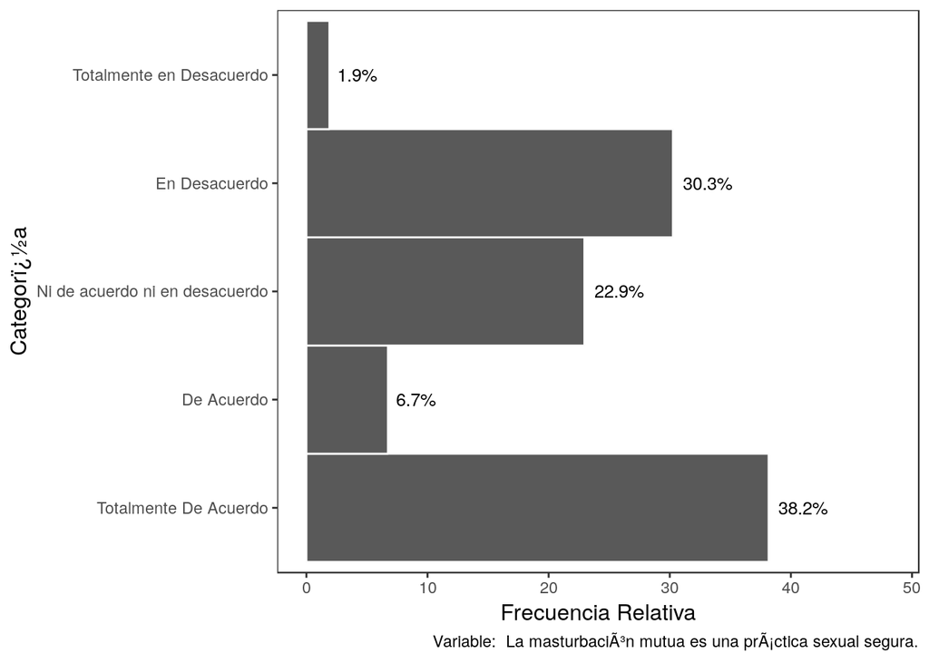